# Mutaciones del gen S asociadas a variantes de preocupación en México, análisis de 582 secuencias virales

José Estrada Miranda y Vadhir Valle Méndez

2025-06-02

## Introducción

En 2020 fuimos testigos de lo que fue una de las crisis mundiales más resonadas de los últimos años. Aunque, afortunadamente, la incidencia de COVID-19 ha disminuido drásticamente en comparación con sus primeros años 2020–2022, gracias a la vacunación y al desarrollo de tratamientos antivirales contra esta enfermedad. Sin embargo, continúan registrándose casos esporádicos y brotes menores causados por nuevas variantes, especialmente en regiones donde es difícil acceder a la vacunación, zonas rurales, etc.

México ha registrado una reducción sostenida en los casos graves y hospitalizaciones por COVID-19. La vigilancia genómica continúa activa, principalmente en aeropuertos y hospitales, para detectar nuevas variantes. La primera variante registrada que fue de verdadera preocupación fue la variante Alfa (B.1.1.7), detectada en el Reino Unido en 2020. Esta contaba con mutaciones características en la proteína Spike. Otras variantes importantes fueron la Beta (Sudáfrica), Gamma (Brasil), Delta (India) y Ómicron (Sudáfrica y Botsuana).

Dada esta información, al equipo nos pareció interesante comenzar a trabajar en la comparación de estas variantes, realizando un análisis comparativo de las mutaciones en el gen Spike (S), específicamente en las variantes que circularon en México desde el inicio de la pandemia hasta 2025. A través del alineamiento de secuencias genómicas usando nuestros conocimientos en R, el proyecto busca identificar y comparar mutaciones clave en el gen Spike (S), especialmente en el dominio RBD (Receptor Binding Domain), que influye directamente en la entrada del virus a las células humanas.

Nuestro objetivo es analizar la frecuencia, tipo e implicaciones de las mutaciones presentes en el gen S del SARS-CoV-2 en un conjunto de 582 secuencias mexicanas, en comparación con la cepa de referencia de Wuhan. A partir de esta comparación, buscamos identificar mutaciones que coincidan con aquellas reportadas en Variantes de Preocupación (VoC), como D614G, T478K y P681H, con el fin de determinar su prevalencia en México, su posible origen local y su rol en la evolución viral. Este análisis pretende responder si dichas mutaciones contribuyeron a la emergencia de variantes dominantes en el país, y si podrían tener impacto en la transmisibilidad o en la eficacia de las vacunas utilizadas durante la pandemia.

Se emplearán secuencias genómicas completas descargadas de bases de datos como GISAID o NCBI. El objetivo es determinar mutaciones comunes y específicas de cada variante que haya circulado en México, y analizar sus posibles implicaciones en la evolución del virus y su interacción con el sistema inmune.

## Tabla de traducción genética

En esta parte nos encargamos de la transcripción, en la cual nos encargamos de traducir las bases nitrogenadas del ADN (A, T, C, G) se “transcriben” al ARN (A, U (uracilo en lugar de timina), C, G).

```r
trad =    c(UUU="F", UUC="F", UUA="L", UUG="L",
            UCU="S", UCC="S", UCA="S", UCG="S",
            UAU="Y", UAC="Y", UAA="STOP", UAG="STOP",
            UGU="C", UGC="C", UGA="STOP", UGG="W",
            CUU="L", CUC="L", CUA="L", CUG="L",
            CCU="P", CCC="P", CCA="P", CCG="P",
            CAU="H", CAC="H", CAA="Q", CAG="Q",
            CGU="R", CGC="R", CGA="R", CGG="R",
            AUU="I", AUC="I", AUA="I", AUG="M",
            ACU="T", ACC="T", ACA="T", ACG="T",
            AAU="N", AAC="N", AAA="K", AAG="K",
            AGU="S", AGC="S", AGA="R", AGG="R",
            GUU="V", GUC="V", GUA="V", GUG="V",
            GCU="A", GCC="A", GCA="A", GCG="A",
            GAU="D", GAC="D", GAA="E", GAG="E",
            GGU="G", GGC="G", GGA="G", GGG="G")
```

## Lectura de secuencias

Una vez que tengamos la transcripción finalizada buscaremos cuáles son los cambios que existen entre la variante principal de Wuhan comparandola con 582 registros de la variante B.1.1.519 que fué descubierta en México.

A continuación podemos observar los cambios que encontramos únicamente centrandonos en el gen Spike (S) organizados en gráficas de barras para facilitar su lectura.

### Mutaciones en los nucleótidos del gen Spike (S)

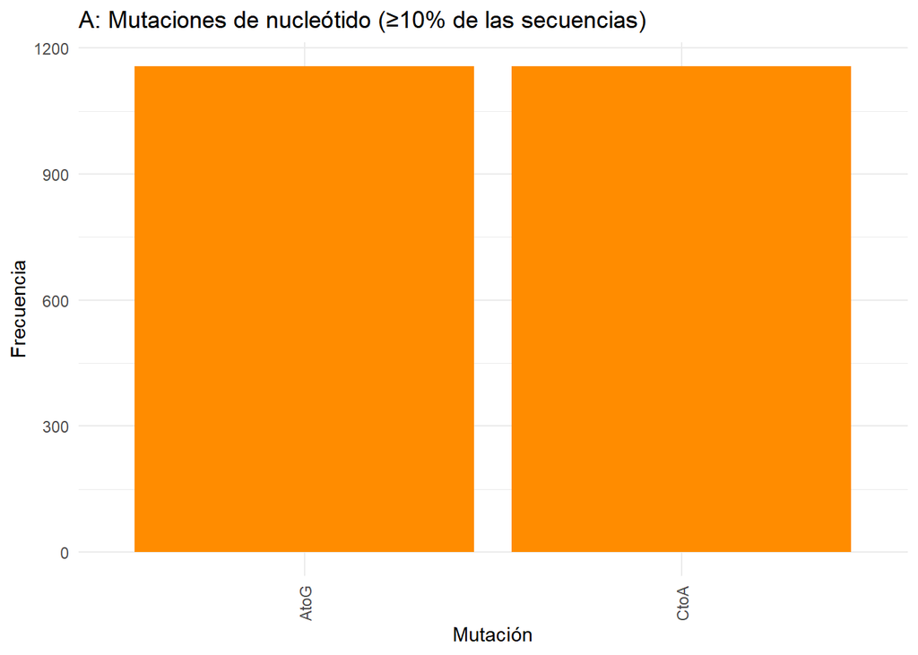

En la gráfica anterior se pueden apreciar las mutaciones de los nucleótidos que se han presentado en el gen Spike.

#### Análisis de la gráfica A

**¿Cómo es que estos cambios en el gen spike afectan a la variante B.1.1.519?**

El genoma del SARS-CoV-2 es ARN, así que está formado por nucleótidos: A (adenina), U (uracilo), G (guanina), C (citosina).

Cuando el virus se replica, mutaciones puntuales pueden cambiar una base por otra:

**AtoG** es una transición que indica un cambio entre purinas ( *componentes clave del ácido nucleico viral (ADN o ARN), que es el material genético que contiene las instrucciones para la replicación del virus* )

**CtoA** es una transversión que indica un cambio entre una pirimidina ( *son uno de los dos tipos de bases nitrogenadas que forman parte de los ácidos nucleicos (ADN y ARN), y son esenciales para la replicación y el funcionamiento de los virus* ) y una purina

Estas mutaciones pueden cambiar aminoácidos en la proteína Spike si ocurren en regiones codificantes

**AtoG** suele causar cambios menos drásticos, pero pueden ser importantes (como D614G)

### Cambios de aminoácidos en el gen Spike (S)

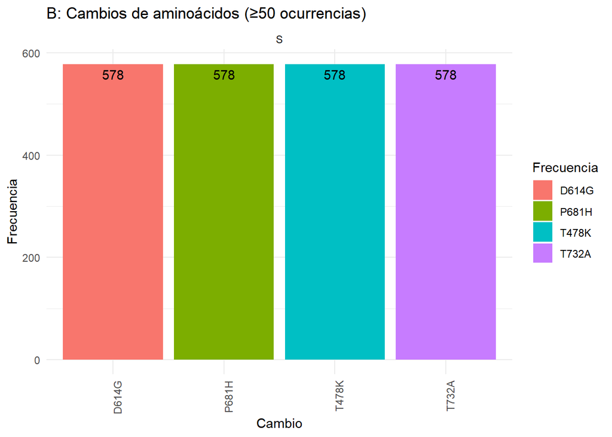

#### Análisis de la gráfica B

**¿Qué es lo que hacen estas mutaciones?**

*D614G:*

La mutación D614G fue una de las primeras en volverse dominante a nivel mundial desde mediados de 2020. Consiste en el cambio de ácido aspártico (D) a glicina (G) en la posición 614 de la proteína Spike. Esta modificación, aunque sutil, provocó un cambio conformacional que aumentó la estabilidad del trímero Spike y facilitó una mayor afinidad por el receptor ACE2 de las células humanas. Como consecuencia, el virus con esta mutación mostró una mayor carga viral en las vías respiratorias superiores y una eficiencia de transmisión significativamente superior, sin un aumento notable en la gravedad de la enfermedad. D614G fue un parteaguas en la pandemia, ya que desplazó rápidamente a las variantes anteriores y preparó el terreno para otras mutaciones adicionales.

*P681H:*

Otra mutación clave es P681H, que se ubica justo adyacente al sitio de escisión por furina entre las subunidades S1 y S2 del Spike. Este cambio de prolina (P) a histidina (H) mejora la eficiencia de corte por furina, lo cual acelera el proceso de entrada viral en las células. Esta mutación ha sido particularmente prevalente en variantes como Alpha (B.1.1.7) y B.1.1.519, y se ha asociado con una mayor fusión celular (formación de sincitios) y un escape parcial a ciertos mecanismos de defensa del hospedero, como las proteínas IFITM. Su presencia favoreció una mayor transmisibilidad, incluso en contextos donde ya dominaba D614G.

**¿Cómo fue su impacto global y regional?**

Estas mutaciones, especialmente en combinación, han tenido efectos visibles en la dinámica de la pandemia. En países como el Reino Unido, la variante Alpha ( *portadora de D614G, P681H, T716I y otras* ) fue responsable de una ola de contagios acelerada a finales de 2020. En México y otros países de América Latina, la variante B.1.1.519, que contiene D614G, P681H y T732A, circuló de forma dominante durante gran parte de 2021, desplazando a linajes anteriores. Estas variantes mostraron una clara ventaja evolutiva en términos de transmisión comunitaria, lo que llevó a aumentos de casos, hospitalizaciones y una presión constante sobre los sistemas de salud.

Además, estas mutaciones impulsaron la necesidad de reforzar la vigilancia genómica y actualizar las vacunas para asegurar una protección más amplia, especialmente ante posibles escapes inmunes.

**¿Por qué esta variante afectó más a México?**

**Surgió y se expandió localmente:** Se detectó por primera vez en la CDMX en noviembre de 2020 y rápidamente aumentó hasta representar ~90 % de los casos en febrero de 2021

**Ventaja competitiva:** En ese periodo, otras variantes como Alpha apenas comenzaban a circular; así que B.1.1.519 dominó primero, desplazando variantes locales previas

**Combinación única de mutaciones:** Las mutaciones T478K, P681H y T732A en Spike le dieron mayor transmisibilidad (mayor Rt) y un ligero aumento en severidad clínica

**¿Qué vacunas se hicieron para combatir esta variante?**

No se desarrolló una vacuna específica para B.1.1.519. En cambio, se usaron vacunas ya existentes (Pfizer-BioNTech, AstraZeneca, CanSino, Sinovac, Sputnik) que se enfocan en la proteína Spike del virus original. Estas vacunas demostraron retener buena neutralización contra B.1.1.519, sin pérdida drástica de eficacia

**¿Por qué surgieron dichas mutaciones?**

Estas mutaciones son típicas de adaptaciones para aumentar transmisión y, en ocasiones, para evadir parcialmente anticuerpos. Su presencia conjunta dio mayor éxito a B.1.1.519 en su momento

**¿Cúales fueron los cambios más importantes que ocurrieron en el gen Spike (S)?**

- Afinidad por receptor: T478K aumenta las interacciones con ACE2.
- Eficiencia de entrada: P681H mejora el corte S1/S2 por furina, esencial para fusionarse con células.
- Estabilidad estructural: D614G estabiliza la forma abierta de Spike, facilitando la unión.
- Fusión celular: T732A puede ayudar a que Spike se fusione mejor luego del corte.

### Mutaciones sobre variantes de preocupación (VoC) en variantes de B.1.1.519

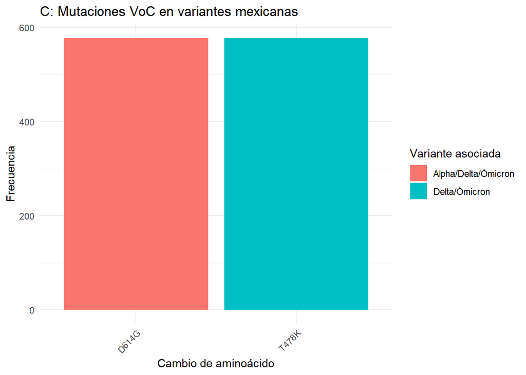

#### Análisis de la gráfica C

En esta gráfica se muestran las mutaciones de la variante B.1.1.519 que coinciden con las variantes de preocupación (VoC), esto con el objetivo de ver que tan peligrosa podemos considerara dicha variante.

Esto también nos ayuda a encontrar coincidencias en las mutaciones de los virus considerados como más peligrosos con otras variantes más inofensivas para saber cuáles son las mutaciones que más fortalecen a el virus y así centrarse solamente en esa mutación para poder neutralizarla con alguna vacuna

**D614G** Se encuentra presente en las variantes de preocupación Alpha, Delta y Omicron. Se encarga de promover una conformación de Spike más “abierta” y estable, mejorando la unión a ACE2 y aumentando la infectividad

**T478K** Se encuentra en Delta y subvariantes de Omicron. Ayuda a incrementar la afinidad por ACE2 y se asocia a menor eficacia neutralizante de anticuerpos

**¿Por qué son importantes estas coincidencias?**

**Convergencia evolutiva:** Cuando variantes independientes desarrollan mutaciones similares, muestra que estas conferen ventajas claras—ya sea mayor transmisión o escape inmunitario

Predicción de comportamiento viral: Saber que B.1.1.519 tiene mutaciones presentes en VOC puede ayudar a anticipar:

- Mayor contagiosidad,
- Posible reducción de efectividad de anticuerpos o vacunas,
- Potencial para superar defensas celulares.

**Guía para vigilancia genética:** Estas mutaciones sirven como “señales de alerta” en secuenciación genómica—indican que una nueva variante podría convertirse en VOI o VOC

**Ajuste de intervenciones:** Si una variante comparte mutaciones con VOC, se pueden adecuar:

- Estrategias de re-secuenciación intensiva
- Vacunas de refuerzo específicas o nuevas
- Protocolos de contención enfocados a mitigar su propagación

### Resumen

La variante B.1.1.519, que predominó en México entre finales de 2020 e inicios de 2021, presentó mutaciones clave en el gen Spike: D614G, T478K, P681H y T732A. Varias de estas también están presentes en variantes de preocupación (VOC) como Delta, Alpha y Omicron. Por ejemplo, D614G se asocia con mayor estabilidad y transmisión, T478K con afinidad aumentada al receptor ACE2 y escape parcial inmune, y P681H con una entrada más eficiente en las células gracias al mejor clivaje por furina. La coincidencia de estas mutaciones con VOC indica una convergencia evolutiva, es decir, diferentes linajes virales adquirieron mutaciones similares porque les brindan ventajas adaptativas como mayor contagiosidad y evasión del sistema inmune. Esto hizo que B.1.1.519 fuera altamente transmisible y clínicamente relevante en el contexto local mexicano.

### Conclusiones

Estudiar las mutaciones compartidas entre variantes emergentes como B.1.1.519 y las variantes de preocupación permite anticipar riesgos epidemiológicos, identificar mutaciones que podrían volver a aparecer y orientar mejor la vigilancia genómica. Además, esta información sirve como base para el desarrollo de vacunas de nueva generación y tratamientos más específicos. En el caso de México, esta investigación ayuda a entender por qué ciertas variantes se vuelven dominantes en contextos locales y cómo se deben ajustar las estrategias de salud pública ante su aparición.

### Bibliografía

Korber, B., et al. (2020). Spike mutation D614G alters SARS-CoV-2 fitness. Nature, 582(7811), 331–335. https://doi.org/10.1038/s41586-020-2734-9

Lorenzo-Redondo, R., et al. (2021). A unique clade of SARS-CoV-2 viruses associated with lower viral loads in patient upper airways. EBioMedicine, 62, 103112. https://doi.org/10.1016/j.ebiom.2020.103112

Peacock, T. P., et al. (2021). The furin cleavage site in the SARS-CoV-2 spike protein is required for transmission in ferrets. Nature Microbiology, 6(7), 899–909. https://doi.org/10.1038/s41564-021-00908-w

Lubinski, B., et al. (2022). P681H mutation in the spike protein enhances SARS-CoV-2 fitness. Journal of Virology, 96(6), e0249221. https://doi.org/10.1128/jvi.02492-21

News-Medical. (2021). How do D614G and P681H mutations alter SARS-CoV-2 infectivity? https://www.news-medical.net/news/20210512/How-do-D614G-and-P681H-mutations-alter-SARS-CoV-2-infectivity.aspx

Wikipedia contributors. (2024). SARS-CoV-2 D614G mutation. In Wikipedia. https://en.wikipedia.org/wiki/SARS-CoV-2_D614G_mutation

Naveca, F. G., et al. (2021). COVID-19 epidemic in the Brazilian state of Amazonas was driven by long-term persistence of endemic lineages and the emergence of the new variant of concern P.1. Nature Medicine, 27(7), 1230–1238. https://doi.org/10.1038/s41591-021-01378-7

Rodríguez-Maldonado, A. P., et al. (2021). Emergence and spread of the SARS-CoV-2 variant B.1.1.519 in Mexico. Journal of Medical Virology, 93(11), 6624–6630. https://doi.org/10.1002/jmv.27293